# Test Assessment

B179416

2024-11-15

## 1 Formative Submission

Perhaps surprisingly, I belong to a special minority. Unlike the thousands of people around me, I (*knocks on wood*) do not have hay fever. Not even a tiny seasonal allergy! I have never known the pains of constant sneezing, allergy-driven insomnia, and never-ending stuffiness. Almost 10 million people in the UK would probably hate me if they knew.

I, however, as a great friend to my poor, hay-feverish friends, have decided to **study the prescription trends and potential environmental relationships** so that I can also be extremely annoying spouting fun facts and claiming I know more about the trends while they suffer in pain. It’s difficult to complain when your throat is dry!

### 1.1 Objective

My research will run through the following journey:

1. What are the **most common antihistaminic** prescriptions (Table)? (Which one should I buy next time they visit?)
2. How do they **change throughout the year** (Plot)? (When should I be on the lookout for signs?)
3. Do antihistaminic prescriptions sold **change around tree-populated areas**? Is it different if I only check known sensitizing trees (Interactive Shiny Geo Plot)? (Should I avoid some areas in the tours I give?)

This will surely equip me with the knowledge needed to be the best guide whenever I get a visit, allowing me to adjust drug stock, and adapt touring locations depending on the month!

## 2 Report

```r
for (package in c("tidyverse","janitor","gt","gtExtras","forcats","ggspatial","osmdata","raster","sf","data.table","scales","flair")) {eval(bquote(library(.(package))))}
```

### 2.1 Datasets

- [“PostalSector.shp”](https://datashare.ed.ac.uk/handle/10283/2597)
- [“GP_Practices_-_Scotland.csv”](https://data.spatialhub.scot/dataset/gp_practices-is/resource/8389fd1d-563d-4c05-9833-26d9f07fd6cd)
- [“Trees.csv”](https://data.edinburghcouncilmaps.info/datasets/cityofedinburgh::trees/about)
- [“NSUL_FEB_2023_SC.csv”](https://geoportal.statistics.gov.uk/datasets/a46903edd1c7435b8fcdca80b0b190db/about) (Subfolder: NSUL_FEB_2023_GB/Data)

The selected antihistaminics are shown below, and were obtained from the NHS Hay Fever treatment recommendations (*https://www.nhs.uk/conditions/antihistamines/*).

```r
prescriptions_202406 <- read_csv("https://www.opendata.nhs.scot/dataset/84393984-14e9-4b0d-a797-b288db64d088/resource/a42762ac-47cb-4fb6-b9b1-2478a588c0ed/download/pitc202403.csv") %>% clean_names()
Postcode_Map <- st_read("C:/Users/Data/Downloads/GB_Postcodes/PostalSector.shp", quiet = TRUE)
Postcode = read.csv("C:/Users/Data/Downloads/GP_Practices_-_Scotland.csv")
Trees = read.csv("C:/Users/Data/Downloads/Trees.csv")
nsul = read.csv("C:/Users/Data/Downloads/NSUL_FEB_2023_SC.csv")

antihist = c("chlorphenamine", "cinnarizine", "diphenhydramine", "hydroxyzine", "promethazine", "acrivastine", "cetirizine", "fexofenadine", "loratadine")

# To access the prescription data, I will be constructing the link dynamically. Each link was seen to have two variable components: the date and the resource number. I have collected them below, ordered in pairs matching index position.
dates = c("202307","202308","202309","202310","202311","202312","202401","202402","202403","202404","202405","202406")
resources = c("7bb45ee6-6f1c-45f4-933b-958bdbe0ca4f","72ca4ad2-0228-4672-9eb0-cc911e4a8ca7","2d3d240f-1467-4a91-9f0e-769745650cb9","94134438-db1d-4b8d-8f70-5e9b0e47bd03","21d11fed-a494-4e30-9bb6-46143c3b9530","00cdf8d7-f784-4e87-894c-34f2540ea6ab","d3eaaf84-0f3b-4fb8-9460-e33503095fbe","86fda652-0e1d-48bb-9368-aa2a560d925b","a42762ac-47cb-4fb6-b9b1-2478a588c0ed","409a02f2-b77c-47a0-917d-4a5a1c90f182","5fbbd126-6166-4249-9620-7ed78e877297","95f7f250-bd04-4e4a-b853-5df75b00a632")
for (date in dates){assign(paste0("prescriptions_", date),read_csv(paste0("https://www.opendata.nhs.scot/dataset/84393984-14e9-4b0d-a797-b288db64d088/resource/",resources[match(date,dates)],"/download/pitc",date,".csv")) %>%  clean_names())} #Assign + paste0 can create objects with varying names inside a loop!
prescriptions_all = rbindlist(lapply(ls(pattern="^prescriptions"), function(x) get(x)))# Create a master df of prescriptions
remove(list = ls(pattern="^prescriptions_2")) # And I remove the individual prescription df to clear space!
```

## 3 Tidying the data

In the following code, I obtain the final prescriptions dataframe, where for each Edinburgh GP, I have an associated number of antihistaminics sold, and its geographical location.

```r
# Working on the prescriptions
antihistamines_data = as.data.frame(c())
for (drug in antihist){
  drug_df = prescriptions_all %>%
    dplyr::filter(str_detect(tolower(bnf_item_description), drug)) %>%
    group_by(gp_practice, date = paid_date_month) %>%
    summarise(drug = drug, paid_quantity = sum(paid_quantity))
  antihistamines_data = rbind(antihistamines_data, drug_df)}
antihist_sold_by_gp = antihistamines_data %>%
  group_by(gp_practice) %>%
  summarise(antihist_sold = sum(paid_quantity))
antihist_sold_by_drug = antihistamines_data %>%
  group_by(drug = str_to_title(drug)) %>%
  summarize(total = sum(as.integer(paid_quantity)),
            proportion = sum(paid_quantity) * 100/ sum(antihistamines_data$paid_quantity)) %>%
  arrange(desc(total))
```

## 4 Table!

```r
# Get a table with how many sales each antihistaminic had
antih_table <- antihist_sold_by_drug %>%
  gt() %>%
  tab_header(title = md("**Antihistaminic Sales in Scotland**"),
             subtitle = "Data from NHS Scotland[...]") %>%
  cols_label(drug = md("**Antihistaminic**"), total = md("**Total Sales**"), proportion = md("**Proportion of<br />Antihistaminic Sales**")) %>%
  data_color(columns = total, method = "numeric", palette = "viridis", reverse = TRUE,
    domain = c(0, max(antihist_sold_by_drug$total))) %>%
  opt_horizontal_padding(scale = 3) %>%
  gt_plt_bar_pct(column = proportion, scaled = TRUE, labels = TRUE, decimals = 2) %>%
  fmt_number(columns = total, sep_mark = ",") %>%
  fmt_percent(columns = proportion, decimals = 2) %>%
  cols_align(align = "center", columns = total:proportion) %>%
  cols_width(everything() ~ px(200)) %>%
  tab_options(column_labels.border.bottom.width = px(2),
    column_labels.border.bottom.color = "black",
    table.border.top.color = "white")

antih_table
```

**Antihistaminic Sales in Scotland**

| **Antihistaminic** | **Total Sales** | Proportion of Antihistaminic Sales |
| --- | --- | --- |
| Cetirizine | 44,479,227.00 | 33.73% |
| Fexofenadine | 32,212,104.00 | 24.43% |
| Chlorphenamine | 29,252,642.00 | 22.18% |
| Loratadine | 12,341,176.00 | 9.36% |
| Promethazine | 6,692,444.00 | 5.07% |
| Cinnarizine | 3,469,256.00 | 2.63% |
| Hydroxyzine | 3,058,185.00 | 2.32% |
| Acrivastine | 353,334.00 | 0.27% |
| Diphenhydramine | 19,959.00 | 0.02% |

## 5 Generate the timeline plot

Note to self: check out plotly! It may be good to generate an interactive plot where people can check the different points / filter on a single drug.

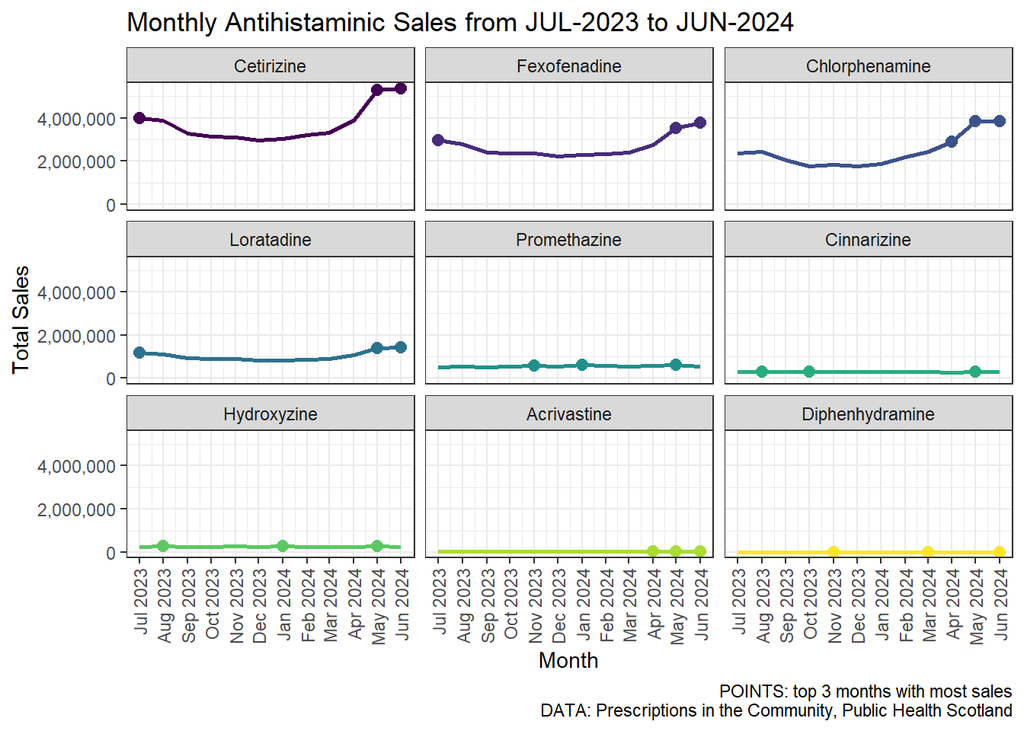

```r
antihist_sold_by_month_and_drug = antihistamines_data %>%
  mutate(date = as.Date(paste0("01",date),format="%d%Y%m")) %>%
  group_by(drug = str_to_title(drug), date) %>%
  summarize(total = sum(as.integer(paid_quantity))) %>%
  mutate(drug = factor(drug, levels = antihist_sold_by_drug$drug, ordered = T))
antihist_sold_by_month_and_drug_3 = antihist_sold_by_month_and_drug %>%
  group_by(drug) %>%
  arrange(desc(total)) %>%
  top_n(3,wt = total)
#-------------------------------------------------------------------------------
month_trend_plot = antihist_sold_by_month_and_drug %>% ggplot(aes(x = date, y = total, group = drug, colour = drug)) +
  geom_line(linewidth = 1) +
  geom_point(data = antihist_sold_by_month_and_drug_3, size = 2.5) +
  facet_wrap(vars(drug)) +
  theme_bw() +
  theme(axis.text.x = element_text(angle = 90, vjust = 0.5, hjust=1),
        legend.position = "none") +
  scale_x_date(date_breaks = "1 month", labels = date_format("%b %Y")) +
  scale_y_continuous(labels = comma) +
  labs(title = "Monthly Antihistaminic Sales from JUL-2023 to JUN-2024",
       x = "Month",
       y = "Total Sales",
       caption = md("POINTS: top 3 months with most sales\nDATA: Prescriptions in the Community, Public Health Scotland"))
month_trend_plot
```

## 6 Generate the map plot!

For now this is a static map, but I intend to make a Shiny Interactive plot that will allow the user to change between viewing ‘all trees’ or filtering for ‘sensitizer trees’, or their choice of tree.

[figure not shown]

```r
# Get the Edinburgh Districts
Postcode_Map_Edi = Postcode_Map %>%
  dplyr::filter(Sprawl == "Edinburgh")

# Get the GP Information
NSUL_Edi = nsul %>% # Find the coordinates of each UPRN
  dplyr::filter(str_detect(PCDS,"EH")) %>%
  rename(Easting = "GRIDGB1E",
         Northing = "GRIDGB1N",
         uprn = UPRN)  %>%
  dplyr::select(Easting, Northing, uprn)
GP_Edi = Postcode %>%
  dplyr::filter(str_detect(postcode,"EH")) %>% # Filter the GPs in Edinburgh
  left_join(., NSUL_Edi, by = "uprn") %>% # Add their coordinates using UPRN
  dplyr::filter(!is.na(Easting)) %>% # Remove GPs with unknown coordinates
  left_join(.,antihist_sold_by_gp, by = c("prac_code" = "gp_practice")) # Add antihistaminics sold
GP_Edi_sf = GP_Edi %>% # Transform into sf points based on Edi Districts and remove empty
  st_as_sf(., coords = c("Easting", "Northing"), crs = st_crs(Postcode_Map_Edi)) %>%
  dplyr::filter(!st_is_empty(geometry))

# Get the the tree coordinates
trees_sf <- st_as_sf(Trees, coords = c("X", "Y"), crs = st_crs(Postcode_Map_Edi))
#-------------------------------------------------------------------------------
# Plot!!!
all_trees_map <- ggplot(Postcode_Map_Edi) +
  annotation_map_tile(type = "osm", zoom = 12, alpha = 0.5) + # Background map
  # Plot the districts, trees, and GPs
  geom_sf(data = Postcode_Map_Edi, fill = alpha("lightgray", 0.2), color = "deeppink", size = 0.5) +
  geom_sf(data = trees_sf, colour = "forestgreen", size = 0.5, shape = "\U0001F332") +
  geom_sf(data = GP_Edi_sf, aes(color = antihist_sold), size = 2, shape = 17) + #"\U0001F3E0") +
  scale_color_viridis_c(option = "inferno", direction = -1) +

  # Adding coordinates, theme and labels
  coord_sf(ylim = c(679577, 657320), xlim = c(306065, 337408)) +
  theme_minimal() +
  labs(title = "Edinburgh: Antihistaminic Prescription in GPs and Tree Location", subtitle = "Prescriptions Data (gradient triangles): March 2024; Tree Data (green tree icons): June 2024", caption = "Edinburgh Map from OpenStreetMap (OSM)", colour = "Antihistaminics Sold") +
  theme(legend.position = "right")

print(all_trees_map)
```

### 6.2 Aesthetics

```r
decorate("Generate montly trend plots") %>% flair_rx("antihist")
```

[output not shown]